# ISA 401: Business Intelligence & Data Visualization

## 20: Commonly Used Charts

### Fall 2026

# Before We Start

1 Join today's Zoom

Use the Zoom link in the [**Week 0 Module**](https://miamioh.instructure.com/courses/258169/modules/981092) on Canvas. **Mute** your mic and **turn off** your video.  
There is no R today. Keep your phone handy for a short game.

2 Today's plan

**Part 1.** A look back at your map.  
**Part 2.** Charts for comparing data.  
**Part 3.** A short phone game, then charts for proportions.  
**Part 4.** Charts for distributions and correlations.

# Where We Are

ISA 401

↓

Phase I

**Data Acquisition & Transformation**  
Aug 24 to Oct 12 (ends with Exam 01)

Phase II (we are here)

**Data Visualization & Communication**  
Oct 14 to Nov 16 (ends with Exam 02)

Phase III

**Exploratory Data Mining & Project Synthesis**  
Nov 18 to Dec 2

**You have the principles, the grammar, and three tools.** Today is about the choice in front of all of them: which chart fits the question?

Phase names and dates from the course schedule on [Canvas](https://miamioh.instructure.com/courses/258169).

# Part 1: Look Back at Your Map

How to get back in

**1.** Open your section's page: [**Section A**](https://isa401-map-gallery.vercel.app/?section=A) or [**Section B**](https://isa401-map-gallery.vercel.app/?section=B).

**2.** On the computer and browser you used in Class 19, your results open by themselves.

**3.** Anywhere else, enter your six-character personal code. Please do not join again with your name.

Lost your code? Email me and I will send it.

What you will find

Your map and how it did in the matchups.

What voters said made it better, and the kinds of ideas classmates would borrow from it.

The maps that beat yours most often, with their pins and final prompts.

**While you look:** what did the map that beat yours do that yours did not?

# Learning Objectives

By the end of today, you should be able to:

1. **Identify** strengths & weaknesses of basic charts.

2. **Use** appropriate charts based on objective.

3. **Test** how accurately you read a chart, using your own answers in today's game.

4. **Avoid** 3D graphs (unless VR changes their utility).

# A Catalog of Commonly Used Graph Types

[interactive chart not shown]

# Chart Suggestions

[figure not shown]

**Source:** [Chart Chooser](https://extremepresentation.typepad.com/blog/2006/09/choosing_a_good.html), created by Andrew Abela in 2006 and last updated on Sept 06, 2020.

# Part 2: Charts Used for Comparing Data

## (Unit of Analysis is Based on a Nominal Categorical Variable)

# A Literal Bar Chart

[figure not shown]

**Task.** Answer the following questions:

**(1)** How many variables do we have in this graph?

**(2)** How many observations?

**(3)** Please discuss the type of variables in the graph (i.e., nominal, ordinal, etc.).

**(4)** How is the data encoded in the graph?

**(5)** Any other comments/observations?

**Source:** The image is from [How Much Does Beer Consumption Vary by Country?](https://snippets.com/how-much-does-beer-consumption-vary-by-country.htm), and the data seems to be based on a 2004 report from the Kirin Holdings Company.

# Two Bar Charts

**Task.** Identify **3-4 differences that make the graph on the right better**, and suggest **how you can further improve the graph on the right**.

[figure not shown]

# Issues with the Interpretation of Bar Charts

[figure not shown]

The Draw Datapoints on Graph (DDoG) measure maintains the graph as a consistent reference frame across its three stages.

**Source:** Kerns and Wilmer (2021). *Journal of Vision*. DOI: 10.1167/jov.21.12.17

# Issues with the Interpretation of Bar Charts

[figure not shown]

Data distribution differs categorically between mean and count graphs. (a) Mean bar graphs and (c) count bar graphs do not differ in basic appearance, but they do depict categorically different data distributions.

**Source:** Kerns and Wilmer (2021). *Journal of Vision*. DOI: 10.1167/jov.21.12.17

# Key Takeaway 1

> The typically used **bar** chart should not be used to depict the means of a numeric variable across categories.

# Waterfall Charts

**Task.** What are the advantages and disadvantages of each chart? They are using the same exact data. Please try to list 2-4 in each category for each chart.

[figure not shown]

# 3D Bar Charts are Awful

[figure not shown]

Adam Grant's Plot of the Penn and Harvard Bar Chart

**Source:** [Adam Grant's tweet](https://twitter.com/AdamMGrant/status/1339925914327638017), December 18, 2020.

# 3D Bar Charts are Awful

[figure not shown]

A remake of the plot with colorblind-friendly colors and a 2D bar representation to avoid distorting the data

# 3D Charts are Awful: Even This

[figure not shown]

**Source:** See the [interactive version of the chart by clicking here](https://codepen.io/zingchart/full/ePxQmd/).

# Part 3: Proportions

# Pie on Trial

How to play

**1.** Scan your section's code. No name and no seat.

**2.** When the game starts, a chart appears on your phone.

**3.** Tap the **largest** slice or bar, or its letter. You have 15 seconds per chart.

**4.** Six charts, about two minutes.

Nothing counts toward your grade. The screen shows only class totals.

Join

Section A (8:30 AM)

[figure not shown]

isa401-pie-on-trial.vercel.app/?section=A

Section B (10:05 AM)

[figure not shown]

isa401-pie-on-trial.vercel.app/?section=B

# My Favorite Pie Chart

[figure not shown]

**Note:** Humor aside, pie charts are almost always awful!!

# Pie Charts are Awful By Design

[figure not shown]

The three datasets from the game. Which slice is largest in each pie?

**Source:** The charts are based on the R code provided in [From-Data-to-Viz: The Issue with Pie Chart](https://www.data-to-viz.com/caveat/pie.html). Values changed so that each dataset sums to 100%.

# Pie Charts are Awful By Design

[figure not shown]

**Rising, flat, falling.** The bars show a pattern the pies hid. Be fair to pies: these values are close on purpose, and pies do better when the differences are large.

# And Often Made Even Worse

3D

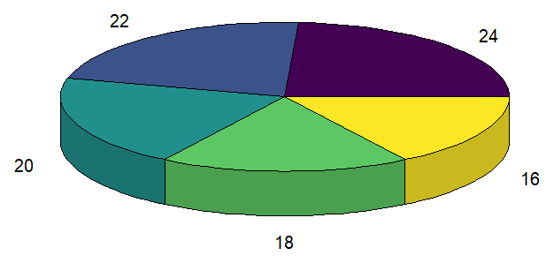

Tilt makes the front slices look larger.

Side legend

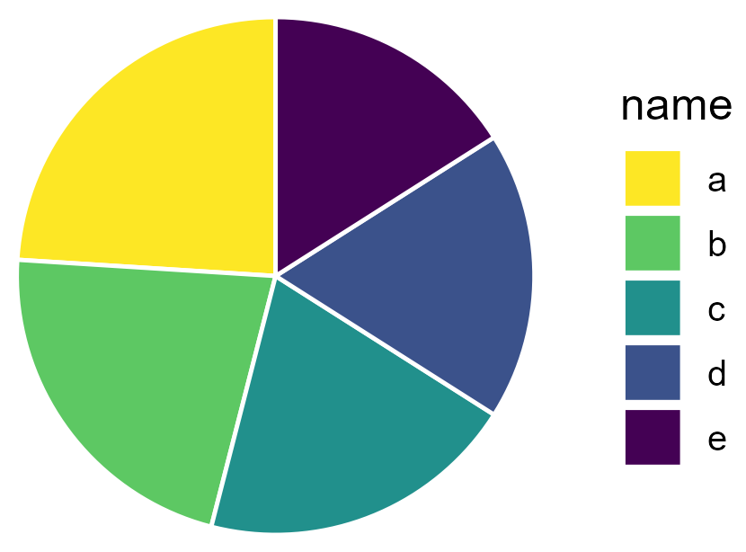

The eye travels back and forth to find each slice's name.

Exploded

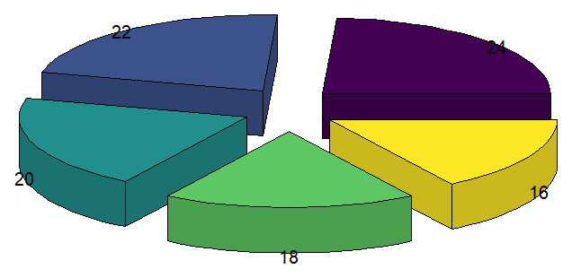

The gaps add nothing, and the slices are harder to compare.

SUM(%) != 100%

[figure not shown]

Fox's slices sum to **193%**.

The first three pies use the same five values (24, 22, 20, 18, 16). A pie's slices only make sense as parts of one whole, and Fox's cannot be.

**Image:** [Fox News chart via FlowingData](https://flowingdata.com/wp-content/uploads/2009/11/Fox-News-pie-chart-620x465.png).

# Key Takeaway 2

> Please do **NOT** use pie charts.

<details style="font-size:14px; line-height:1.4;">
<summary>If you need any further evidence, please check <i>?pie()</i> in R. Even statistical software are recommending against using pie charts!!</summary>

<b>Note</b>

Pie charts are <b>a very bad way of displaying information</b>. The eye is good at judging linear measures and bad at judging relative areas. A bar chart or dot chart is a preferable way of displaying this type of data.

Cleveland (1985), page 264: “Data that can be shown by pie charts always can be shown by a dot chart. <b>This means that judgements of position along a common scale can be made instead of the less accurate angle judgements</b>.”

This statement is based on the empirical investigations of Cleveland and McGill as well as investigations by perceptual psychologists.

</details>

[figure not shown]

# Stacked Bar Charts

**Task.** When is it best to use the four charts below? They are using the same exact data.

[figure not shown]

# A Note on Stacked Bar Charts

[figure not shown]

**Source:** [Storytelling with Data: To Stack or Not to Stack](https://www.storytellingwithdata.com/blog/2012/11/to-stack-or-not-to-stack)

# A Note on Stacked Bar Charts

[figure not shown]

**Source:** [Storytelling with Data: To Stack or Not to Stack](https://www.storytellingwithdata.com/blog/2012/11/to-stack-or-not-to-stack)

# A Note on Stacked Bar Charts

[figure not shown]

**Source:** [Storytelling with Data: To Stack or Not to Stack](https://www.storytellingwithdata.com/blog/2012/11/to-stack-or-not-to-stack)

# Part 4: Distributions and Correlations

# Issues with Histograms

[figure not shown]

**Source:** In a quality improvement project with a major manufacturer of electronic devices, we discovered an issue in the customer's seemingly 'normal' data.

# Issues with Box Plots

[figure not shown]

**Source:** [Nick Desbarats (2021) I've Stopped Using Box Plots. Should You?](https://nightingaledvs.com/ive-stopped-using-box-plots-should-you/)

# Issues with Box Plots

[figure not shown]

**Source:** [Nick Desbarats (2021) I've Stopped Using Box Plots. Should You?](https://nightingaledvs.com/ive-stopped-using-box-plots-should-you/)

# Additional Issues with Box Plots

[figure not shown]

**Source:** [Albert Rapp (2024) Issues with Box Plots](https://www.linkedin.com/posts/dr-albert-rapp-9a5b9b28b_datavisualization-activity-7255217415628746752-YcAG?utm_source=combined_share_message&utm_medium=member_desktop)

# Key Takeaway 3

> To capture the variability in a dataset, the use of box plots **may not be** appropriate!!!!

# Ohio Pays Less in 21 of 23 Occupations

[figure not shown]

**Scatter plots** show the relationship and the exceptions at once. Each dot is an occupation. **r = 0.95:** occupations that pay more nationally also pay more in Ohio. Below the dashed line, Ohio pays less. These wages are not adjusted for cost of living.

**Data:** BLS Occupational Employment and Wage Statistics, May 2025 (`data/oews_2025_business_occupations.csv`, from the Class 19 lab).

# Recap

# Summary of Main Points

- Identify strengths & weaknesses of basic charts

- Use appropriate charts based on objective

- Avoid using pie charts (never use pie charts)

- Avoid 3D graphs (unless VR changes their utility)

# Before Next Class

**Wednesday, Nov 4:** see the course schedule on [Canvas](https://miamioh.instructure.com/courses/258169) for the topic.

Suggested

Wilke, *Fundamentals of Data Visualization*: [**ch. 10, Visualizing proportions**](https://clauswilke.com/dataviz/visualizing-proportions.html).

Free online. When pies, stacked bars, and side-by-side bars each work.

[**To Stack or Not to Stack**](https://www.storytellingwithdata.com/blog/2012/11/to-stack-or-not-to-stack) (Storytelling with Data, 2012).

The full post behind today's three stacked charts.

Skim if curious

Kerns and Wilmer (2021). [**Two graphs walk into a bar**](https://doi.org/10.1167/jov.21.12.17). *Journal of Vision*, 21(12), 17.

The study behind Key Takeaway 1.

Desbarats (2021). [**I've Stopped Using Box Plots. Should You?**](https://nightingaledvs.com/ive-stopped-using-box-plots-should-you/)

The argument behind Key Takeaway 3.